# Correlation Matrix

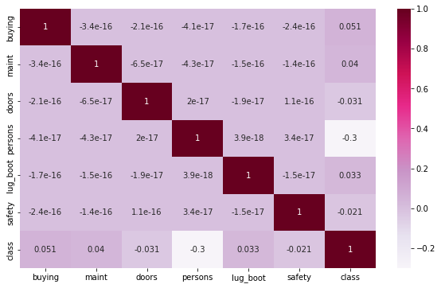

```python
fig=plt.figure(figsize=(10,6))
sns.heatmap(ds.corr(), cmap="PuRd", annot=True)
```

From the above heatmap, it can be observed that most of the columns show very weak correlation with 'class'. So, doing any analysis on them may not give any productive output.

```python
x = ds[ds.columns[:-1]]
y = ds['class']
```

```python
x.head(5)
```

|  | buying | maint | doors | persons | lug_boot | safety |
| --- | --- | --- | --- | --- | --- | --- |
| 0 | 3 | 3 | 0 | 0 | 2 | 1 |
| 1 | 3 | 3 | 0 | 0 | 2 | 2 |
| 2 | 3 | 3 | 0 | 0 | 2 | 0 |
| 3 | 3 | 3 | 0 | 0 | 1 | 1 |
| 4 | 3 | 3 | 0 | 0 | 1 | 2 |

```python
from sklearn.model_selection import train_test_split
x_train, x_test, y_train, y_test = train_test_split(x, y, test_size=0.3, random_state=42)
```

# Model Selection

```python
#Task 3 Train multiple classifiers and compare the accuracy.

from sklearn.model_selection import learning_curve
from sklearn.linear_model import LogisticRegression
from sklearn.neighbors import KNeighborsClassifier
from sklearn.model_selection import cross_val_score
from sklearn.metrics import classification_report, confusion_matrix
```

1. Logistic Regression

```python
logreg=LogisticRegression(solver='newton-cg',multi_class='multinomial')
```

```python
logreg.fit(x_train,y_train)
```

```
LogisticRegression(multi_class='multinomial', solver='newton-cg')
```

```python
pred=logreg.predict(x_test)
```

```python
logreg.score(x_test,y_test)
```

```
0.6647398843930635
```

Logistic regression model is giving very less accuracy.

# 2. KNN Classifier

```python
Knn = KNeighborsClassifier(n_jobs = -1)
```

```python
Knn.fit(x_train,y_train)
pred=Knn.predict(x_test)
Knn.score(x_test,y_test)
```

```
0.9132947976878613
```

```python
print(classification_report(y_test,pred))
```

```
              precision    recall  f1-score   support

           0       0.87      0.77      0.82       118
           1       0.67      0.53      0.59        19
           2       0.93      1.00      0.96       358
           3       1.00      0.67      0.80        24

    accuracy                           0.91       519
   macro avg       0.87      0.74      0.79       519
weighted avg       0.91      0.91      0.91       519
```

Accuracy can't be a fair criterion to evaluate unbalanced classification, so check 'f1-score' f1-score is 0.9 which is better than previous model

```python
avg_score=[]
for k in range(2,30):
    knn=KNeighborsClassifier(n_jobs=-1,n_neighbors=k)
    score=cross_val_score(knn,x_train,y_train,cv=5,n_jobs=-1,scoring='accuracy')
    avg_score.append(score.mean())
```

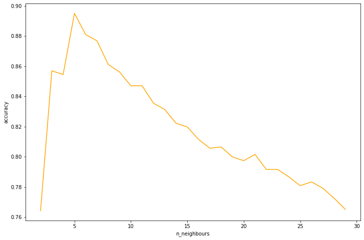

```python
plt.figure(figsize=(12,8))
plt.plot(range(2,30),avg_score, color = 'orange')
plt.xlabel("n_neighbours")
plt.ylabel("accuracy")
```

So, with KNN Classification algorithm, it is able to achieve accuracy of 90%

# 3. Random Forests Classifier

```python
from sklearn.ensemble import RandomForestClassifier
from sklearn.metrics import f1_score
```

```python
rfc=RandomForestClassifier(n_jobs=-1,random_state=51)
```

```python
rfc.fit(x_train,y_train)
print(rfc.score(x_test,y_test))
print(f1_score(y_test,rfc.predict(x_test),average='macro'))
```

```
0.9730250481695568
0.9245337130459484
```

RFC is providing 97% accuracy which is quite impressive.

```python
!pip3 install xgboost
```

```python
from xgboost import XGBClassifier
xgboost=XGBClassifier()
xgboost.fit(x_train,y_train)
```

[output not shown]

```
XGBClassifier(base_score=0.5, booster='gbtree', colsample_bylevel=1,
              colsample_bynode=1, colsample_bytree=1, enable_categorical=False,
              gamma=0, gpu_id=-1, importance_type=None,
              interaction_constraints='', learning_rate=0.300000012,
              max_delta_step=0, max_depth=6, min_child_weight=1, missing=nan,
              monotone_constraints='()', n_estimators=100, n_jobs=8,
              num_parallel_tree=1, objective='multi:softprob', predictor='auto',
              random_state=0, reg_alpha=0, reg_lambda=1, scale_pos_weight=None,
              subsample=1, tree_method='exact', validate_parameters=1,
              verbosity=None)
```

```python
from sklearn.metrics import confusion_matrix, accuracy_score
y_pred = xgboost.predict(x_test)
cm = confusion_matrix(y_test, y_pred)
print(cm)
accuracy_score(y_test, y_pred)
```

```
[[112   5   0   1]
 [  1  17   0   1]
 [  0   0 358   0]
 [  1   1   0  22]]
```

```
0.9807321772639692
```

```python
from sklearn.model_selection import cross_val_score
accuracies = cross_val_score(estimator = xgboost, X = x_train, y = y_train, cv = 10)
print("Accuracy:{:.2f} %".format(accuracies.mean()*100))
print("Standard Deviation:{:.2f} %".format(accuracies.std()*100))
```

[output not shown]

The overall accuracy for our model is 98.26% which is pretty cool. So is this is the highest accuracy that we can achieve.